# CollegeMajors

# Female to Male distribution in STEM majors

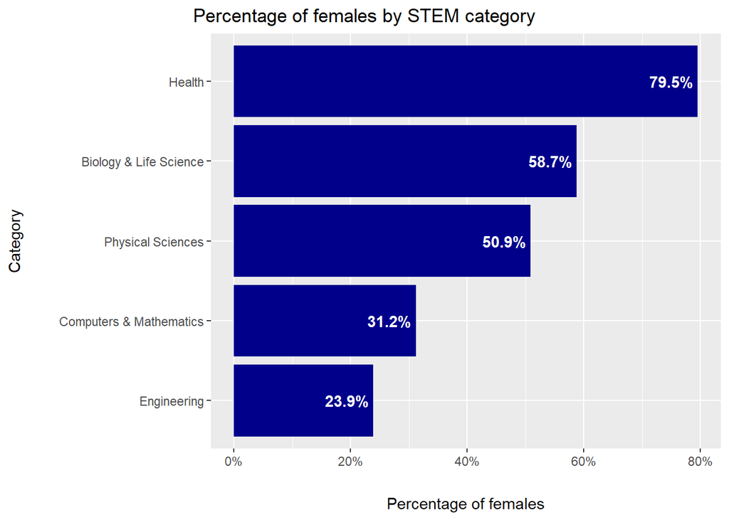

```r
collegeWomenData %>%
  group_by(Major_category) %>%
  summarize(ShareWomen=mean(ShareWomen)) %>%
  ggplot()+
  geom_col(mapping=aes(x=ShareWomen, y= reorder(Major_category, ShareWomen)),fill="darkblue")+
  labs(title= "Percentage of females by STEM category")+ xlab("Percentage of females") + ylab("Category")+
  theme(axis.title.x = element_text(margin = margin(t = 20, r = 0, b = 0, l = 0)),axis.title.y = element_text(margin = margin(t = 0, r = 25, b = 0, l = 0)),plot.title = element_text(hjust = 0.5),plot.title.position = "plot")+
  scale_x_continuous(labels=scales::percent_format())+
  geom_text(aes(x = ShareWomen, y = reorder(Major_category, ShareWomen), label= paste0(format(ShareWomen*100,digits=3), "%")), color="white",fontface="bold",hjust = 1.1)
```

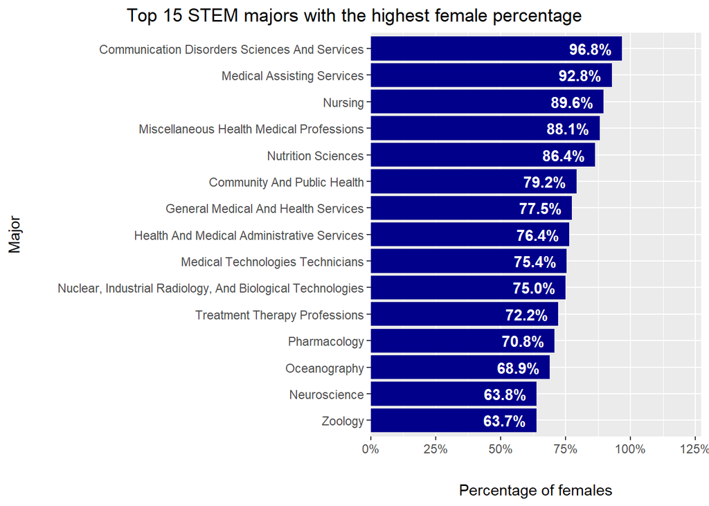

```r
collegeWomenData %>%
  arrange(desc(ShareWomen)) %>%
  mutate(Major = str_to_title(Major)) %>%
  slice(1:15) %>%
  ggplot(aes(x = reorder(Major, ShareWomen), y = ShareWomen,
             label= paste0(format(ShareWomen*100,digits=3), "%"))) +
  geom_col(fill = "darkblue") +
  geom_text(hjust = 1.3, nudge_y = .01, color="white", fontface="bold") +
  labs(title= "Top 15 STEM majors with the highest female percentage") +
  ylab("Percentage of females") + xlab("Major") +
  theme(axis.title.x = element_text(margin = margin(t = 20, r = 0, b = 0, l = 0)),
        axis.title.y = element_text(margin = margin(t = 0, r = 25, b = 0, l = 0)),
        plot.title = element_text(hjust = 0.5),
        plot.title.position = "plot")+
  scale_y_continuous(labels = percent_format(),expand = expansion(mult = c(0, .3))) +
  coord_flip()
```

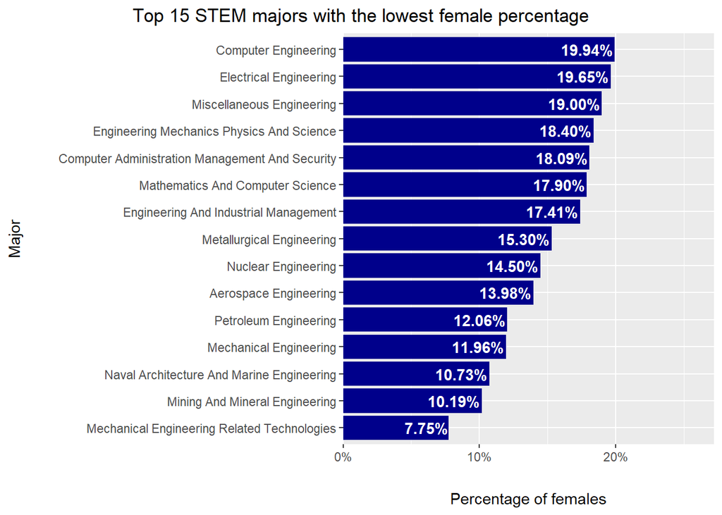

```r
collegeWomenData %>%
  arrange(ShareWomen) %>%
  mutate(Major = str_to_title(Major)) %>%
  slice(1:15) %>%
  ggplot(aes(x = reorder(Major, ShareWomen), y = ShareWomen,
             label= paste0(format(ShareWomen*100,digits=3), "%"))) +
  geom_col(fill = "darkblue") +
  geom_text(hjust = 1.3, nudge_y = .01, color="white", fontface="bold") +
  labs(title= "Top 15 STEM majors with the lowest female percentage") +
  ylab("Percentage of females") + xlab("Major") +
  theme(axis.title.x = element_text(margin = margin(t = 20, r = 0, b = 0, l = 0)),
        axis.title.y = element_text(margin = margin(t = 0, r = 25, b = 0, l = 0)),
        plot.title = element_text(hjust = 0.5),
        plot.title.position = "plot")+
  scale_y_continuous(labels = percent_format(),expand = expansion(mult = c(0, .3))) +
  coord_flip()
```

### Female distribution insights:

- Science is at the top of the list of options for STEM majors for female students, while technology and mechanics are at the bottom.

# Unemployment

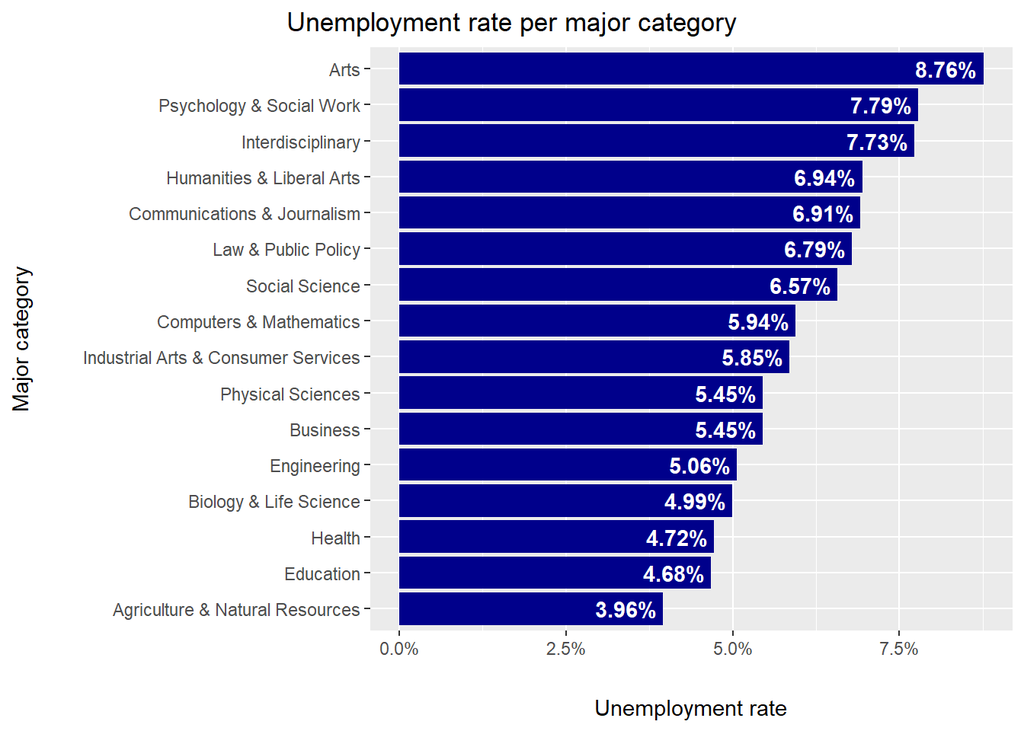

```r
collegeData %>%
  group_by(Major_category) %>%
  summarise(average_rate= mean(Unemployment_rate)) %>%
  ggplot()+
  geom_col(mapping=aes(x=average_rate, y=reorder(Major_category, average_rate)), fill="darkblue")+
  theme(axis.title.x = element_text(margin = margin(t = 20, r = 0, b = 0, l = 0)),axis.title.y = element_text(margin = margin(t = 0, r = 25, b = 0, l = 0)),plot.title = element_text(hjust = 0.5),plot.title.position = "plot")+
  labs(title= "Unemployment rate per major category") + xlab("Unemployment rate")+ ylab("Major category")+
  scale_x_continuous(labels=scales::percent_format())+
  geom_text(aes(x = average_rate, y = reorder(Major_category, average_rate), label= paste0(format(average_rate*100,digits=3), "%")), color="white",fontface="bold",hjust = 1.1)
```

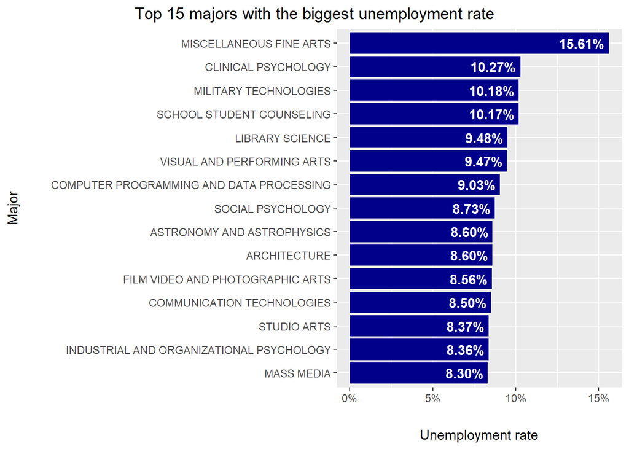

```r
collegeData %>%
  group_by(Major) %>%
  summarise(average_rate= mean(Unemployment_rate)) %>%
  arrange(desc(average_rate)) %>%
  slice(1:15) %>%
  ggplot()+
  geom_col(mapping=aes(x=average_rate, y=reorder(Major, average_rate)), fill="darkblue")+
  theme(axis.title.x = element_text(margin = margin(t = 20, r = 0, b = 0, l = 0)) , axis.title.y = element_text(margin = margin(t = 0, r = 25, b = 0, l = 0)),plot.title = element_text(hjust = 0.5),plot.title.position = "plot")+
  labs(title= "Top 15 majors with the biggest unemployment rate") + xlab("Unemployment rate")+ ylab("Major")+
  scale_x_continuous(labels=scales::percent_format())+
  geom_text(aes(x = average_rate, y = reorder(Major, average_rate), label= paste0(format(average_rate*100,digits=3), "%")), color="white",fontface="bold",hjust = 1.1)
```

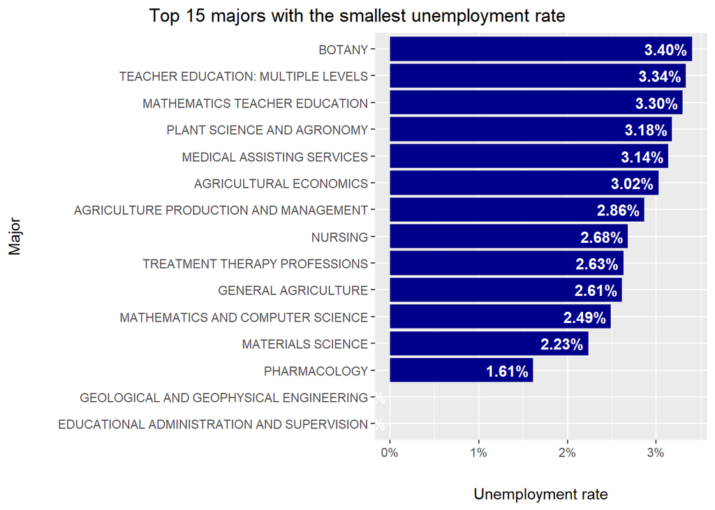

```r
collegeData %>%
  group_by(Major) %>%
  summarise(average_rate= mean(Unemployment_rate)) %>%
  arrange(average_rate) %>%
  slice(1:15) %>%
  ggplot()+
  geom_col(mapping=aes(x=average_rate, y=reorder(Major, average_rate)), fill="darkblue")+
  theme(axis.title.x = element_text(margin = margin(t = 20, r = 0, b = 0, l = 0)) , axis.title.y = element_text(margin = margin(t = 0, r = 25, b = 0, l = 0)),plot.title = element_text(hjust = 0.5),plot.title.position = "plot")+
  labs(title= "Top 15 majors with the smallest unemployment rate") + xlab("Unemployment rate")+ ylab("Major")+
  scale_x_continuous(labels=scales::percent_format())+
  geom_text(aes(x = average_rate, y = reorder(Major, average_rate), label= paste0(format(average_rate*100,digits=3), "%")), color="white",fontface="bold",hjust = 1.1)
```

### Unemployment insights

- Interdisciplinary is the third category with the biggest unemployment rate while being the one with the least students.
- The arts majors have the highest unemployment rate.
- Miscellaneous Fine Arts accompanies it’s category, Arts, being the major with the highest unemployment rate.
- Military technology is the third least popular major and has the third highest unemployment rate.
- The fact that educational administration and supervision is one of the majors that launches fewer students into the job market may contribute to the fact that all of those considered in the survey are employed.
- Geological and geophysical engineering, like the previous major, has a small student body and no unemployment.